# Proyecto clustering

Joel Ramirez

2025

El proyecto se realizará con base en el conjunto de datos denominado dataset.csv que contiene 4 columnas en especifico con cada variable de distinto tipo:

1. Codificacion - SystemCodeNumber (Identificacion del estacionamiento)
2. Capacidad - Capacity (Capacidad máxima del estacionamiento)
3. Ocupacion - Occupancy (Puestos ocupados)
4. Ultima actualizacion de los datos - (actualizacion del tiempo en ese momento)

Ello aplicado para estacionamientos en los parques nacionales de USA.

El objetivo es agrupar en clusters los estacionamientos que se comportan de manera similar y posteriormente describir sus caracteristicas mediante la técnica denominada K-MEANS. Esta estrategia permitira seleccionar representantes de grupo y hacer predicciones sobre la ocupacion o equivalentemente disponibilidad de los mismos.

Obtengo el archivo y lo muestro en consola:

```r
df = read.csv("C:/Users/User/OneDrive/Desktop/EJERCICIOS R/DATA MINING/clustering/dataset.csv", sep=",", header = TRUE)

#Visualizamos las primeras 6 filas:
head(df)
```

```
##   SystemCodeNumber Capacity Occupancy         LastUpdated
## 1      BHMBCCMKT01      577        61 2016-10-04 07:59:42
## 2      BHMBCCMKT01      577        64 2016-10-04 08:25:42
## 3      BHMBCCMKT01      577        80 2016-10-04 08:59:42
## 4      BHMBCCMKT01      577       107 2016-10-04 09:32:46
## 5      BHMBCCMKT01      577       150 2016-10-04 09:59:48
## 6      BHMBCCMKT01      577       177 2016-10-04 10:26:49
```

Tipos de datos que se tienen

```r
sapply(df, class)
```

```
## SystemCodeNumber         Capacity        Occupancy      LastUpdated
##      "character"        "integer"        "integer"      "character"
```

Se muestran cuantas filas y columnas hay

```r
dim(df)
```

```
## [1] 35717     4
```

### PREPARACION DE LOS DATOS

Janitor sirve para limpiar los nombres de las columnas y contar los valores faltantes en ella

```r
library(janitor)
# Garantizo que los nombres de las columnas sean solo letras,
# numeros o guiones bajos
df = clean_names(df)
print(head(df))
```

```
##   system_code_number capacity occupancy        last_updated
## 1        BHMBCCMKT01      577        61 2016-10-04 07:59:42
## 2        BHMBCCMKT01      577        64 2016-10-04 08:25:42
## 3        BHMBCCMKT01      577        80 2016-10-04 08:59:42
## 4        BHMBCCMKT01      577       107 2016-10-04 09:32:46
## 5        BHMBCCMKT01      577       150 2016-10-04 09:59:48
## 6        BHMBCCMKT01      577       177 2016-10-04 10:26:49
```

Separamos la columna en fecha y hora

```r
# Convertir la columna a POSIXct si es necesario
df$last_updated <- as.POSIXct(df$last_updated, format = "%Y-%m-%d %H:%M:%S", tz = "UTC")

df$fecha <- as.Date(df$last_updated)  # Extraer la fecha
df$hora <- format(df$last_updated, "%H:%M:%S")  # Extraer la hora

#install.packages("lubridate")  # Solo si no está instalado
library(lubridate)
# Convertir la columna 'hora' a un objeto de hora
df$hora <- hms(df$hora)

library(dplyr)
# Eliminar la columna 'last_updated' usando subset
df <- subset(df, select = -last_updated)

head(df)
```

```
##   system_code_number capacity occupancy      fecha        hora
## 1        BHMBCCMKT01      577        61 2016-10-04  7H 59M 42S
## 2        BHMBCCMKT01      577        64 2016-10-04  8H 25M 42S
## 3        BHMBCCMKT01      577        80 2016-10-04  8H 59M 42S
## 4        BHMBCCMKT01      577       107 2016-10-04  9H 32M 46S
## 5        BHMBCCMKT01      577       150 2016-10-04  9H 59M 48S
## 6        BHMBCCMKT01      577       177 2016-10-04 10H 26M 49S
```

Tipos de datos que se tienen ahora

```r
sapply(df, class)
```

```
## system_code_number           capacity          occupancy              fecha
##        "character"          "integer"          "integer"             "Date"
##               hora
##           "Period"
```

Verificamos si hay falores faltantes y cuantos son

```r
print(sapply(df, function(x) sum(is.na(x))))
```

```
## system_code_number           capacity          occupancy              fecha
##                  0                  0                  0                  0
##               hora
##                  0
```

Obtenemos los dias de la semana que corresponde a cada fecha:

```r
df <- df %>%
  mutate(dia = wday(fecha, label = TRUE, abbr = FALSE))

head(df)
```

```
##   system_code_number capacity occupancy      fecha        hora    dia
## 1        BHMBCCMKT01      577        61 2016-10-04  7H 59M 42S martes
## 2        BHMBCCMKT01      577        64 2016-10-04  8H 25M 42S martes
## 3        BHMBCCMKT01      577        80 2016-10-04  8H 59M 42S martes
## 4        BHMBCCMKT01      577       107 2016-10-04  9H 32M 46S martes
## 5        BHMBCCMKT01      577       150 2016-10-04  9H 59M 48S martes
## 6        BHMBCCMKT01      577       177 2016-10-04 10H 26M 49S martes
```

Obtenemos el mes:

```r
df$mes <- format(df$fecha, "%B")
head(df)
```

```
##   system_code_number capacity occupancy      fecha        hora    dia     mes
## 1        BHMBCCMKT01      577        61 2016-10-04  7H 59M 42S martes octubre
## 2        BHMBCCMKT01      577        64 2016-10-04  8H 25M 42S martes octubre
## 3        BHMBCCMKT01      577        80 2016-10-04  8H 59M 42S martes octubre
## 4        BHMBCCMKT01      577       107 2016-10-04  9H 32M 46S martes octubre
## 5        BHMBCCMKT01      577       150 2016-10-04  9H 59M 48S martes octubre
## 6        BHMBCCMKT01      577       177 2016-10-04 10H 26M 49S martes octubre
```

Eliminamos la columna fecha:

```r
df <- subset(df, select = -fecha)
head(df)
```

```
##   system_code_number capacity occupancy        hora    dia     mes
## 1        BHMBCCMKT01      577        61  7H 59M 42S martes octubre
## 2        BHMBCCMKT01      577        64  8H 25M 42S martes octubre
## 3        BHMBCCMKT01      577        80  8H 59M 42S martes octubre
## 4        BHMBCCMKT01      577       107  9H 32M 46S martes octubre
## 5        BHMBCCMKT01      577       150  9H 59M 48S martes octubre
## 6        BHMBCCMKT01      577       177 10H 26M 49S martes octubre
```

Reorganizamos las columnas:

```r
df <- df[, c("system_code_number", "capacity", "occupancy", "mes", "dia", "hora")]
head(df)
```

```
##   system_code_number capacity occupancy     mes    dia        hora
## 1        BHMBCCMKT01      577        61 octubre martes  7H 59M 42S
## 2        BHMBCCMKT01      577        64 octubre martes  8H 25M 42S
## 3        BHMBCCMKT01      577        80 octubre martes  8H 59M 42S
## 4        BHMBCCMKT01      577       107 octubre martes  9H 32M 46S
## 5        BHMBCCMKT01      577       150 octubre martes  9H 59M 48S
## 6        BHMBCCMKT01      577       177 octubre martes 10H 26M 49S
```

## DATA CLEANING

```r
df_prueba = data.frame(df)
head(df_prueba)
```

```
##   system_code_number capacity occupancy     mes    dia        hora
## 1        BHMBCCMKT01      577        61 octubre martes  7H 59M 42S
## 2        BHMBCCMKT01      577        64 octubre martes  8H 25M 42S
## 3        BHMBCCMKT01      577        80 octubre martes  8H 59M 42S
## 4        BHMBCCMKT01      577       107 octubre martes  9H 32M 46S
## 5        BHMBCCMKT01      577       150 octubre martes  9H 59M 48S
## 6        BHMBCCMKT01      577       177 octubre martes 10H 26M 49S
```

Estacionamientos registrados:

```r
tabla_frecuencias <- table(df_prueba$system_code_number)

# Contar el número de estacionamientos registrados
print(tabla_frecuencias)
```

```
##
##      BHMBCCMKT01      BHMBCCPST01      BHMBCCSNH01      BHMBCCTHL01
##             1312             1276             1294             1312
##      BHMBRCBRG01      BHMBRCBRG02      BHMBRCBRG03      BHMBRTARC01
##             1186             1186             1186               88
##      BHMEURBRD01      BHMEURBRD02      BHMMBMMBX01      BHMNCPHST01
##             1312             1276             1312             1312
##      BHMNCPLDH01      BHMNCPNHS01      BHMNCPNST01      BHMNCPPLS01
##             1292             1038             1312             1291
##      BHMNCPRAN01     Broad Street        Bull Ring    NIA Car Parks
##             1186             1312             1186             1204
##        NIA North        NIA South Others-CCCPS105a Others-CCCPS119a
##              162             1204             1312             1312
##  Others-CCCPS133 Others-CCCPS135a  Others-CCCPS202    Others-CCCPS8
##             1294             1312             1312             1312
##   Others-CCCPS98         Shopping
##             1312             1312
```

Número de estacionamientos registrados:

```r
numero_est <- length(tabla_frecuencias)
print(numero_est)
```

```
## [1] 30
```

Resumen del dataframe:

```r
summary(df_prueba)
```

```
##  system_code_number    capacity      occupancy          mes
##  Length:35717       Min.   : 220   Min.   :  -8.0   Length:35717
##  Class :character   1st Qu.: 500   1st Qu.: 210.0   Class :character
##  Mode  :character   Median : 849   Median : 446.0   Mode  :character
##                     Mean   :1398   Mean   : 642.2
##                     3rd Qu.:2009   3rd Qu.: 798.0
##                     Max.   :4675   Max.   :4327.0
##
##         dia            hora
##  domingo  :4764   Min.   :7H 30M 33S
##  lunes    :5400   1st Qu.:10H 0M 5S
##  martes   :5461   Median :12H 4M 36S
##  miércoles:5461   Mean   :12H 13M 49.263851947253S
##  jueves   :4983   3rd Qu.:14H 29M 49S
##  viernes  :4968   Max.   :16H 34M 28S
##  sábado   :4680
```

Diagrama de caja de estacionamientos vs puestos ocupados

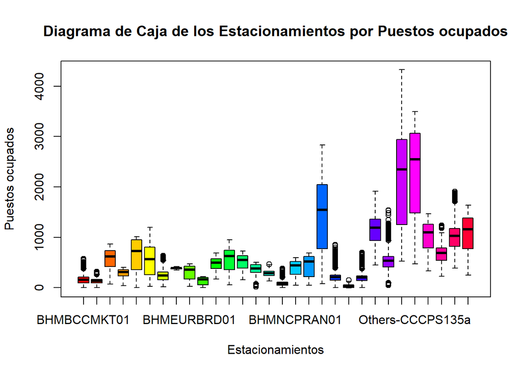

```r
library(dplyr)

boxplot(occupancy ~ system_code_number, data = df_prueba,
        main = "Diagrama de Caja de los Estacionamientos por Puestos ocupados",
        xlab = "Estacionamientos",
        ylab = "Puestos ocupados",
        col = rainbow(length(unique(df$system_code_number))))  # Usar colores diferentes para cada estacionamiento
```

```r
# Crear un data frame vacío para almacenar los resultados
outliers_list <- data.frame()

# Creamos el dataframe para guardar los datos limpios
df_cleaned <- df_prueba

# Iterar sobre cada system_code_number
for (code in unique(df_prueba$system_code_number)) {

  # Filtrar el data frame para el system_code_number actual
  subset_data <- df_prueba[df_prueba$system_code_number == code, ]

  # Calcular Q1 y Q3
  Q1 <- quantile(subset_data$occupancy, 0.25)
  Q3 <- quantile(subset_data$occupancy, 0.75)

  # Calcular el IQR
  IQR_value <- IQR(subset_data$occupancy)

  # Definir límites para identificar outliers
  lower_bound <- Q1 - 1.5 * IQR_value
  upper_bound <- Q3 + 1.5 * IQR_value

  # Identificar valores atípicos
  outliers <- subset_data[subset_data$occupancy < lower_bound | subset_data$occupancy > upper_bound, ]

  # Agregar los resultados a la lista de outliers
  outliers_list <- rbind(outliers_list, outliers)

  # Filtrar el data frame para eliminar valores atípicos
  df_cleaned <- df_cleaned[!(df_cleaned$system_code_number == code &
                               (df_cleaned$occupancy < lower_bound |
                                  df_cleaned$occupancy > upper_bound)), ]
}
```

Comparamos los dataframes con y sin valores atipicos:

```r
summary(df)
```

```
##  system_code_number    capacity      occupancy          mes
##  Length:35717       Min.   : 220   Min.   :  -8.0   Length:35717
##  Class :character   1st Qu.: 500   1st Qu.: 210.0   Class :character
##  Mode  :character   Median : 849   Median : 446.0   Mode  :character
##                     Mean   :1398   Mean   : 642.2
##                     3rd Qu.:2009   3rd Qu.: 798.0
##                     Max.   :4675   Max.   :4327.0
##
##         dia            hora
##  domingo  :4764   Min.   :7H 30M 33S
##  lunes    :5400   1st Qu.:10H 0M 5S
##  martes   :5461   Median :12H 4M 36S
##  miércoles:5461   Mean   :12H 13M 49.263851947253S
##  jueves   :4983   3rd Qu.:14H 29M 49S
##  viernes  :4968   Max.   :16H 34M 28S
##  sábado   :4680
```

```r
summary(df_cleaned)
```

```
##  system_code_number    capacity      occupancy        mes
##  Length:35169       Min.   : 220   Min.   :  -8   Length:35169
##  Class :character   1st Qu.: 500   1st Qu.: 208   Class :character
##  Mode  :character   Median : 863   Median : 445   Mode  :character
##                     Mean   :1398   Mean   : 642
##                     3rd Qu.:2009   3rd Qu.: 797
##                     Max.   :4675   Max.   :4327
##
##         dia            hora
##  domingo  :4630   Min.   :7H 30M 33S
##  lunes    :5355   1st Qu.:9H 59M 52S
##  martes   :5461   Median :12H 4M 2S
##  miércoles:5433   Mean   :12H 12M 12.55526173619S
##  jueves   :4934   3rd Qu.:14H 29M 8S
##  viernes  :4922   Max.   :16H 34M 28S
##  sábado   :4434
```

Diagramas de caja de estacionamientos vs puestos ocupados

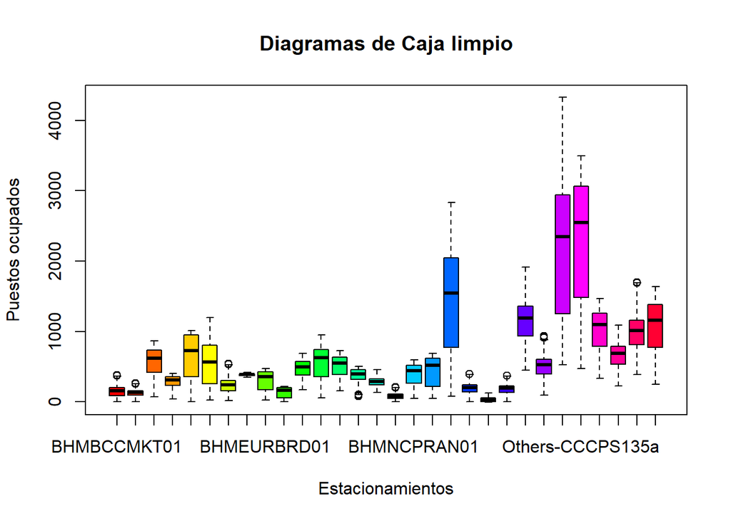

```r
boxplot(occupancy ~ system_code_number, data = df_cleaned,
        main = "Diagramas de Caja limpio",
        xlab = "Estacionamientos",
        ylab = "Puestos ocupados",
        col = rainbow(length(unique(df$system_code_number))))  # Usar colores diferentes para cada estacionamiento
```

Ahora tenemos el conjunto de datos limpio

```r
df = df_cleaned
head(df)
```

```
##   system_code_number capacity occupancy     mes    dia        hora
## 1        BHMBCCMKT01      577        61 octubre martes  7H 59M 42S
## 2        BHMBCCMKT01      577        64 octubre martes  8H 25M 42S
## 3        BHMBCCMKT01      577        80 octubre martes  8H 59M 42S
## 4        BHMBCCMKT01      577       107 octubre martes  9H 32M 46S
## 5        BHMBCCMKT01      577       150 octubre martes  9H 59M 48S
## 6        BHMBCCMKT01      577       177 octubre martes 10H 26M 49S
```

### EXPLORACION DE DATOS

Histogramas por estacionamiento (primeros 15):

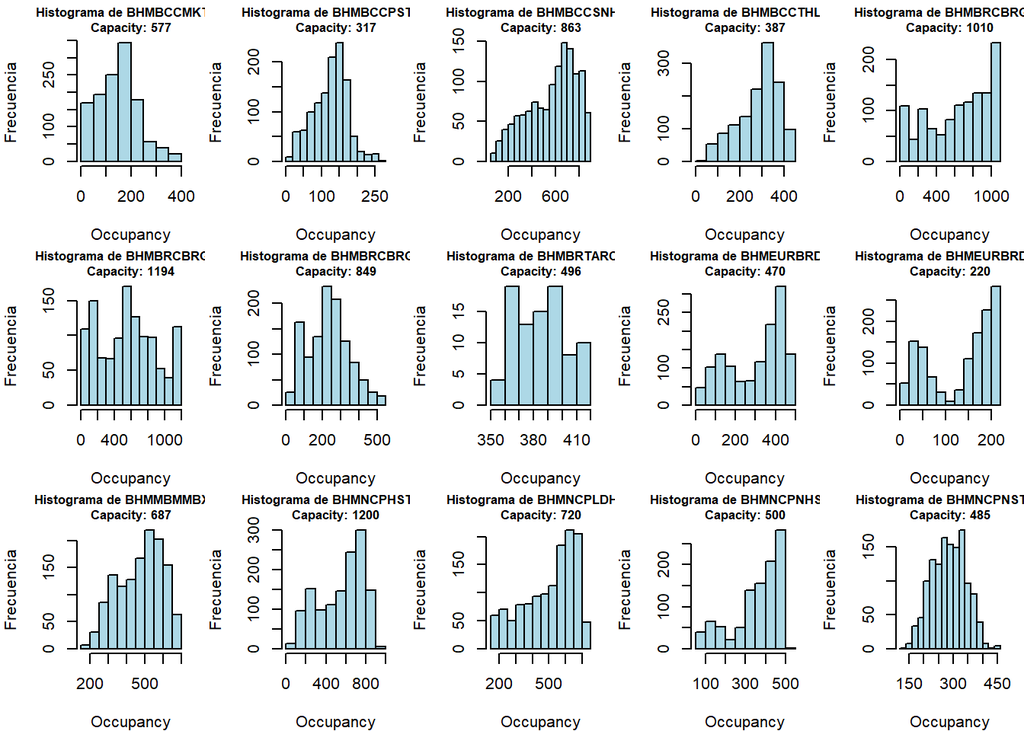

```r
# Configurar la disposición de los gráficos para los primeros histogramas
par(mfrow = c(3, 5), mar = c(4, 4, 2, 1))  # 3 fila y 5 columnas

# Crear histogramas para los primeros
for (code in unique(df$system_code_number)[1:15]) {
  subset_data <- df[df$system_code_number == code, ]

  # Calcular el valor máximo de capacity
  max_capacity <- max(subset_data$capacity)

  hist(subset_data$occupancy,
       main = paste("Histograma de", code, "\nCapacity:", max_capacity),  # Título del histograma,  # Título del histograma
       xlab = "Occupancy",                    # Etiqueta del eje X
       ylab = "Frecuencia",                   # Etiqueta del eje Y
       col = "lightblue",                     # Color de las barras
       border = "black",
       cex.main = 0.8)                      # Color del borde de las barras
}
```

Histogramas por estacionamiento (ultimos 15):

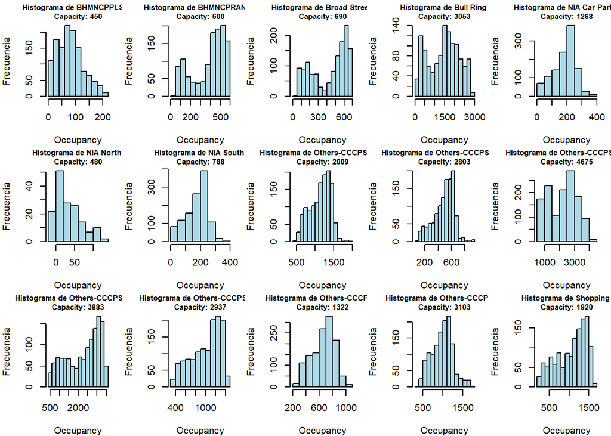

```r
# Configurar la disposición de los gráficos para los histogramas
par(mfrow = c(3, 5), mar = c(4, 4, 2, 1))  # 3 filas y 5 columnas


# Crear histogramas
for (code in unique(df$system_code_number)[16:30]) {
  subset_data <- df[df$system_code_number == code, ]

  # Calcular el valor máximo de capacity
  max_capacity <- max(subset_data$capacity)

  hist(subset_data$occupancy,
       main = paste("Histograma de", code, "\nCapacity:", max_capacity),  # Título del histograma,  # Título del histograma
       xlab = "Occupancy",                    # Etiqueta del eje X
       ylab = "Frecuencia",                   # Etiqueta del eje Y
       col = "lightblue",                     # Color de las barras
       border = "black",
       cex.main = 0.8)                      # Color del borde de las barras
}
```

Diagramas de barras

Diagrama de barras del estacionamiento y las horas en que tiene puestos ocupados, horas (eje x) vs ocupados (eje y)

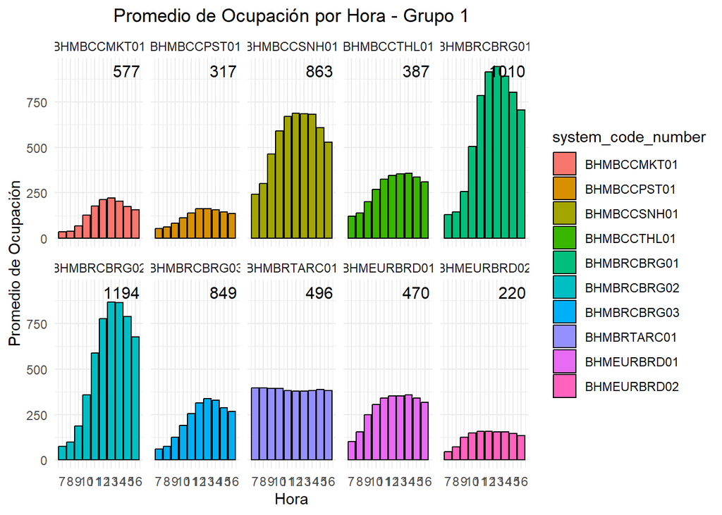

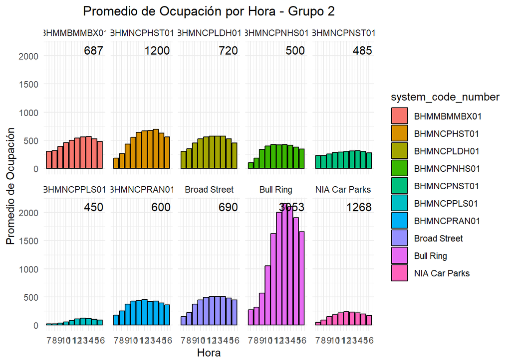

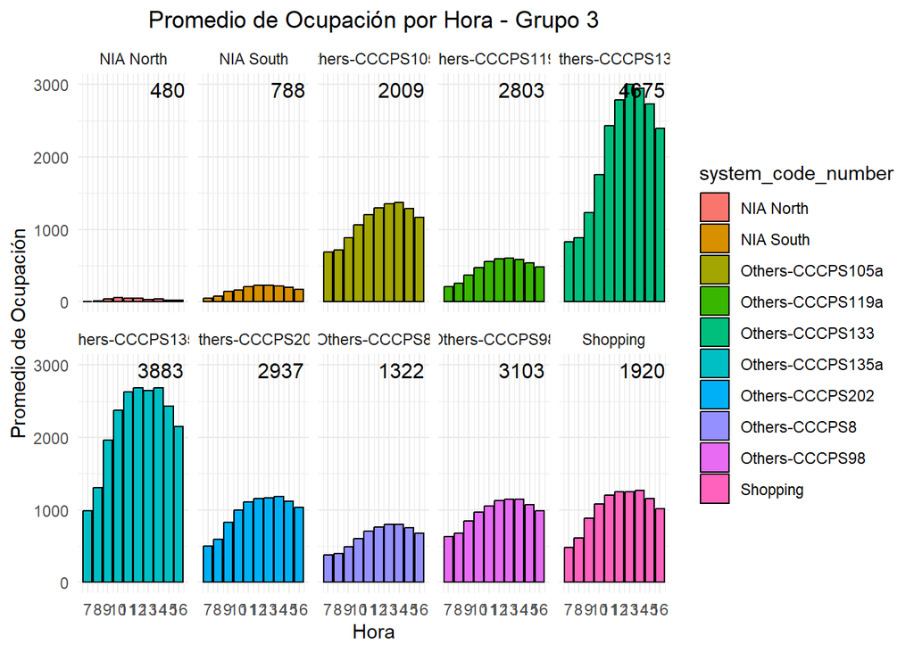

```r
# install.packages("ggplot2")
library(ggplot2)
library(dplyr)
library(tidyr)

# Convertir hora a formato numérico
df$hora_num <- as.numeric(sub("H.*", "", df$hora))

# Calcular el promedio de ocupación y el máximo de capacidad por system_code_number y hora
df_summary <- df %>%
  group_by(system_code_number, hora_num) %>%
  summarise(promedio_occupancy = mean(occupancy, na.rm = TRUE),
            max_capacity = max(capacity, na.rm = TRUE), .groups = 'drop') %>%
  ungroup()

# Dividir los system_code_number en grupos de 10
unique_codes <- unique(df_summary$system_code_number)
num_groups <- ceiling(length(unique_codes) / 10)

# Crear gráficos de 10 en 10
for (i in 0:(num_groups - 1)) {
  # Obtener el grupo actual de system_code_number
  current_codes <- unique_codes[(i * 10 + 1):min((i + 1) * 10, length(unique_codes))]

  # Filtrar el resumen para el grupo actual
  df_group <- df_summary %>% filter(system_code_number %in% current_codes)


  # Crear el gráfico de barras para el grupo actual
  p <- ggplot(df_group, aes(x = hora_num, y = promedio_occupancy, fill = system_code_number)) +
    geom_bar(stat = "identity", position = "dodge", color = "black") +
    scale_x_continuous(breaks = 7:16) +
    labs(title = paste("Promedio de Ocupación por Hora - Grupo", i + 1),
         x = "Hora",
         y = "Promedio de Ocupación") +
    theme_minimal() +
    facet_wrap(~ system_code_number, nrow = 2, ncol = 5) +  # Ajustar filas y columnas
    geom_text(aes(label = ""),
              position = position_dodge(width = 0.9),
              vjust = -0.5, size = 3) +  # Añadir el valor máximo de capacidad como texto
    theme(plot.title = element_text(hjust = 0.5))  # Centrar el título

  # Añadir el valor de capacidad debajo del título
  capacity_label <- df_group %>%
    group_by(system_code_number) %>%
    summarise(capacity = unique(max_capacity))

  p <- p + geom_text(data = capacity_label,
                     aes(label = capacity),
                     x = Inf, y = Inf,
                     vjust = 1.5, hjust = 1.1, size = 4)  # Ajustar la posición según sea necesario

  # Mostrar el gráfico
  print(p)
}
```

CORRELACIONES

Se debe verificar si hay correlaciones entre las variables que no se van a predecir. De ser así, debe salir una de ellas del modelo

```r
df_copia <- data.frame(df)
```

Calcular la matriz de correlación

Convertir variables categóricas a numéricas

```r
sapply(df, class)
```

```
## $system_code_number
## [1] "character"
##
## $capacity
## [1] "integer"
##
## $occupancy
## [1] "integer"
##
## $mes
## [1] "character"
##
## $dia
## [1] "ordered" "factor"
##
## $hora
## [1] "Period"
## attr(,"package")
## [1] "lubridate"
##
## $hora_num
## [1] "numeric"
```

```r
df_copia$system_code_number <- as.numeric(factor(df_copia$system_code_number))
df_copia$mes <- as.numeric(factor(df_copia$mes))
df_copia$dia <- as.numeric(factor(df_copia$dia))

# Ahora se puede calcular la matriz de correlación
correlacion_matriz <- cor(df_copia[, c("system_code_number", "capacity", "occupancy", "mes", "dia","hora")])
print(correlacion_matriz)
```

```
##                    system_code_number     capacity   occupancy          mes
## system_code_number       1.0000000000  0.674626119  0.48120035  0.015974838
## capacity                 0.6746261192  1.000000000  0.77559957 -0.005840613
## occupancy                0.4812003521  0.775599571  1.00000000 -0.063329467
## mes                      0.0159748378 -0.005840613 -0.06332947  1.000000000
## dia                      0.0045944518  0.007828897  0.03744717 -0.043146502
## hora                     0.0004239343 -0.002476906 -0.01064622  0.004829673
##                             dia          hora
## system_code_number  0.004594452  0.0004239343
## capacity            0.007828897 -0.0024769057
## occupancy           0.037447166 -0.0106462174
## mes                -0.043146502  0.0048296732
## dia                 1.000000000 -0.1388810148
## hora               -0.138881015  1.0000000000
```

Visualizar la matriz de correlación

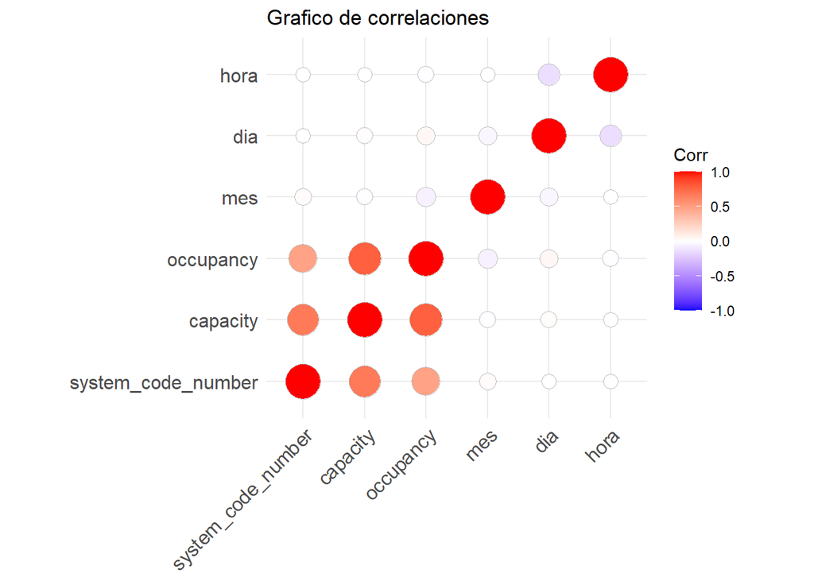

```r
library(ggcorrplot)
plot(ggcorrplot(correlacion_matriz, method = "circle", title = "Grafico de correlaciones"))
```

```r
# En el grafico se visualizará cuan relacionadas están.
```

Estacionamientos con mayores probabilidades de estar desocupado por cada hora

```r
# Extraer la hora de la columna hora
df$hour <- as.numeric(gsub("H.*$", "", df$hora))

# Calcular el porcentaje de puestos desocupados
df$porcentaje_desocupado <- round(((df$capacity - df$occupancy) / df$capacity * 100), 2)

# Calcular promedio por código y hora
resultado <- df %>%
  group_by(system_code_number, hour) %>%
  summarise(
    porcentaje_desocupado = mean(porcentaje_desocupado)
  ) %>%
  ungroup()
# Mostrar resultados
print("Promedio de porcentaje de puestos desocupados por código y hora:")
```

```
## [1] "Promedio de porcentaje de puestos desocupados por código y hora:"
```

```r
print(resultado)
```

```
## # A tibble: 300 × 3
##    system_code_number  hour porcentaje_desocupado
##    <chr>              <dbl>                 <dbl>
##  1 BHMBCCMKT01            7                  93.7
##  2 BHMBCCMKT01            8                  93.1
##  3 BHMBCCMKT01            9                  88.1
##  4 BHMBCCMKT01           10                  77.9
##  5 BHMBCCMKT01           11                  69.3
##  6 BHMBCCMKT01           12                  63.2
##  7 BHMBCCMKT01           13                  61.4
##  8 BHMBCCMKT01           14                  64.7
##  9 BHMBCCMKT01           15                  69.8
## 10 BHMBCCMKT01           16                  73.0
## # ℹ 290 more rows
```

Creamos el grafico para los primeros 10 estacionamientos:

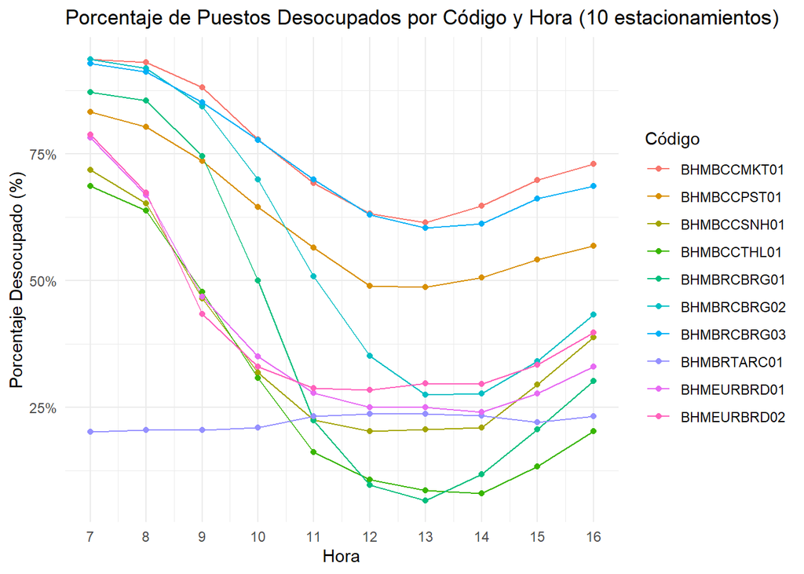

```r
codigos_a_mostrar <- unique(resultado$system_code_number)[1:10]

# Filtrar el dataframe para esos códigos
resultado_filtrado <- resultado %>%
  filter(system_code_number %in% codigos_a_mostrar)

# Crear gráfico con los 10 códigos seleccionados
ggplot(resultado_filtrado, aes(x = hour, y = porcentaje_desocupado, color = system_code_number)) +
  geom_line() +
  geom_point() +
  labs(
    title = "Porcentaje de Puestos Desocupados por Código y Hora (10 estacionamientos)",
    x = "Hora",
    y = "Porcentaje Desocupado (%)",
    color = "Código"
  ) +
  theme_minimal() +
  scale_x_continuous(breaks = 7:16) +
  scale_y_continuous(labels = function(x) paste0(x, "%"))
```

Luego los próximos 10:

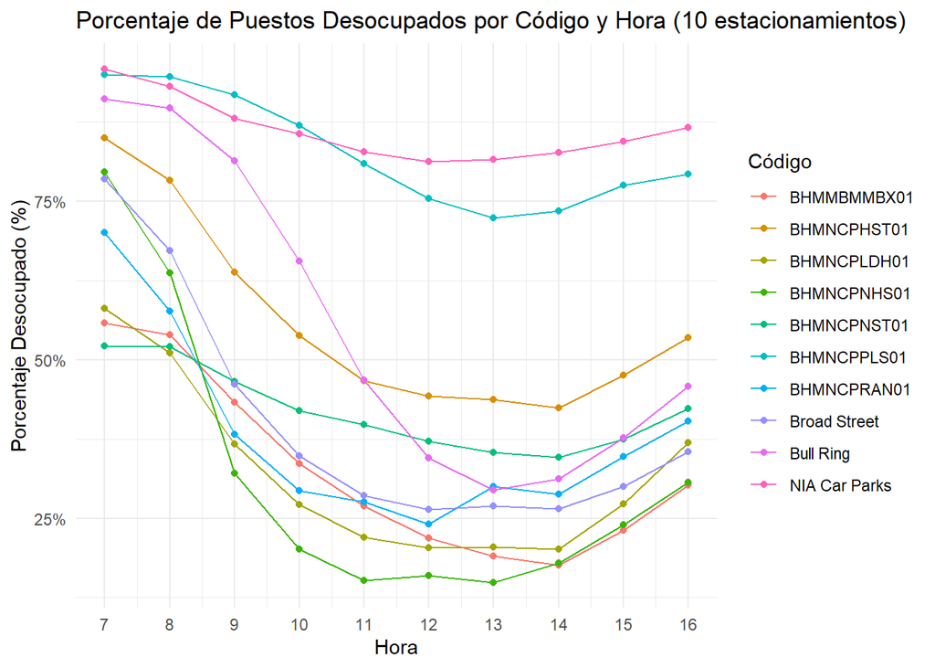

```r
codigos_a_mostrar <- unique(resultado$system_code_number)[11:20]

# Filtrar el dataframe para esos códigos
resultado_filtrado <- resultado %>%
  filter(system_code_number %in% codigos_a_mostrar)

# Crear gráfico con los 10 códigos seleccionados
ggplot(resultado_filtrado, aes(x = hour, y = porcentaje_desocupado, color = system_code_number)) +
  geom_line() +
  geom_point() +
  labs(
    title = "Porcentaje de Puestos Desocupados por Código y Hora (10 estacionamientos)",
    x = "Hora",
    y = "Porcentaje Desocupado (%)",
    color = "Código"
  ) +
  theme_minimal() +
  scale_x_continuous(breaks = 7:16) +
  scale_y_continuous(labels = function(x) paste0(x, "%"))
```

Ultimos 10:

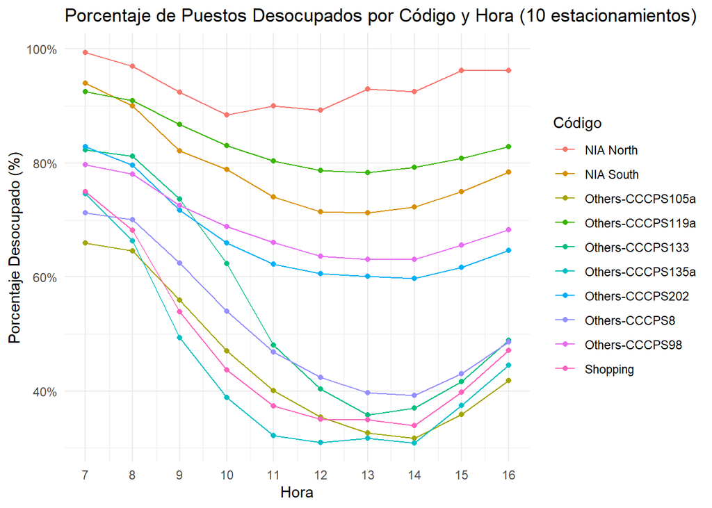

```r
codigos_a_mostrar <- unique(resultado$system_code_number)[21:30]

# Filtrar el dataframe para esos códigos
resultado_filtrado <- resultado %>%
  filter(system_code_number %in% codigos_a_mostrar)

# Crear gráfico con los 10 códigos seleccionados
ggplot(resultado_filtrado, aes(x = hour, y = porcentaje_desocupado, color = system_code_number)) +
  geom_line() +
  geom_point() +
  labs(
    title = "Porcentaje de Puestos Desocupados por Código y Hora (10 estacionamientos)",
    x = "Hora",
    y = "Porcentaje Desocupado (%)",
    color = "Código"
  ) +
  theme_minimal() +
  scale_x_continuous(breaks = 7:16) +
  scale_y_continuous(labels = function(x) paste0(x, "%"))
```

```r
df_copy = df
head(df_copy)
```

```
##   system_code_number capacity occupancy     mes    dia        hora hora_num
## 1        BHMBCCMKT01      577        61 octubre martes  7H 59M 42S        7
## 2        BHMBCCMKT01      577        64 octubre martes  8H 25M 42S        8
## 3        BHMBCCMKT01      577        80 octubre martes  8H 59M 42S        8
## 4        BHMBCCMKT01      577       107 octubre martes  9H 32M 46S        9
## 5        BHMBCCMKT01      577       150 octubre martes  9H 59M 48S        9
## 6        BHMBCCMKT01      577       177 octubre martes 10H 26M 49S       10
##   hour porcentaje_desocupado
## 1    7                 89.43
## 2    8                 88.91
## 3    8                 86.14
## 4    9                 81.46
## 5    9                 74.00
## 6   10                 69.32
```

# Analisis

Tecnica para separar en clusters seleccionada: K-means

#### Justificacion:

K-means es un algoritmo de clustering no supervisado que se utiliza para agrupar datos en un número predefinido de clusters (k), Ni KNN ni el método jerarquico los es.

Es generalmente más rápido y escalable que KNN y el método jerárquico, especialmente con grandes conjuntos de datos, por lo que, resulta adaptarse mas a nuestro caso.

## Funcionamiento del algoritmo

1. Inicialización de Centroides

El primer paso consiste en seleccionar un número predefinido de clústeres, denotado como k. Luego, se inicializan los centroides de estos clústeres. Esto puede hacerse de varias maneras, como:

Aleatoramente : Seleccionando k puntos aleatorios del conjunto de datos como centroides iniciales.

K-means++: Un método que elige los centroides iniciales de manera que estén más dispersos, lo que ayuda a mejorar la convergencia del algoritmo.

2. Asignación de Clústeres

Una vez que los centroides están inicializados, el algoritmo asigna cada punto de datos al clúster cuyo centroide es el más cercano. Esta cercanía se mide generalmente utilizando la distancia euclidiana. Cada punto se asigna al clúster que minimiza la distancia entre el punto y el centroide.

3. Recalculo de Centroides

Después de que todos los puntos han sido asignados a clústeres, se recalculan los centroides de cada clúster. Esto se hace tomando el promedio de todos los puntos asignados a cada clúster. El nuevo centroide se convierte en el punto medio de los datos que pertenecen a ese clúster.

4. Verificación de Convergencia

El algoritmo verifica si ha alcanzado la convergencia. Esto se puede hacer de varias maneras, pero comúnmente se evalúa si los centroides han cambiado significativamente desde la última iteración. Si el cambio en la posición de los centroides es menor que un umbral predefinido (tolerancia), o si no hay cambios en la asignación de clústeres, el algoritmo se considera convergido.

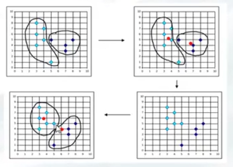

5. Iteración

Si el algoritmo no ha convergido, se repiten los pasos 2 y 3: se reasignan los puntos a los clústeres basándose en los nuevos centroides y se recalculan los centroides nuevamente. Este proceso se repite hasta que se cumpla el criterio de convergencia o se alcance un número máximo de iteraciones.

6. Resultados Finales

Una vez que el algoritmo ha convergido, se obtienen los clústeres finales y sus centroides. Estos resultados pueden ser utilizados para análisis posteriores, como la visualización de los clústeres o la interpretación de patrones en los datos.

## Pasos para usar K-MEANS

1. Transformación de Variables:

Antes de aplicar K-means, nos aseguramos de que los datos estén en un formato adecuado. Esto puede incluir la conversión de variables categóricas a numéricas y limpiamos los atipicos

```r
# Tipos de datos que se tienen
sapply(df, class)
```

```
## $system_code_number
## [1] "character"
##
## $capacity
## [1] "integer"
##
## $occupancy
## [1] "integer"
##
## $mes
## [1] "character"
##
## $dia
## [1] "ordered" "factor"
##
## $hora
## [1] "Period"
## attr(,"package")
## [1] "lubridate"
##
## $hora_num
## [1] "numeric"
##
## $hour
## [1] "numeric"
##
## $porcentaje_desocupado
## [1] "numeric"
```

```r
# Cambiamos a factor numerico: mes, dia y hora
meses_espanol <- c("enero", "febrero", "marzo", "abril", "mayo", "junio",
                   "julio", "agosto", "septiembre", "octubre", "noviembre", "diciembre")

# Cambiamos a factor numerico: mes, dia y hora
df$mes <- as.numeric(factor(df$mes, levels = meses_espanol))
df$dia <- as.numeric(factor(df$dia))
df$hora <- as.numeric(df$hora, units = "secs")

head(df)
```

```
##   system_code_number capacity occupancy mes dia  hora hora_num hour
## 1        BHMBCCMKT01      577        61  10   3 28782        7    7
## 2        BHMBCCMKT01      577        64  10   3 30342        8    8
## 3        BHMBCCMKT01      577        80  10   3 32382        8    8
## 4        BHMBCCMKT01      577       107  10   3 34366        9    9
## 5        BHMBCCMKT01      577       150  10   3 35988        9    9
## 6        BHMBCCMKT01      577       177  10   3 37609       10   10
##   porcentaje_desocupado
## 1                 89.43
## 2                 88.91
## 3                 86.14
## 4                 81.46
## 5                 74.00
## 6                 69.32
```

2. Escalado de Datos:

Dado que K-means es sensible a la escala de los datos, es crucial normalizar o estandarizar las variables. Esto asegura que todas las características contribuyan de manera equitativa al cálculo de distancias.

```r
#instalar paquete "factoextra" si no lo esta:
if (!requireNamespace("factoextra", quietly = TRUE)) {
  install.packages("factoextra")
}

library(factoextra)
# Instalar el paquete si no está instalado
if (!requireNamespace("cluster", quietly = TRUE)) {
  install.packages("cluster")
}

# install.packages("ggalt")  # Si no está instalado
library(ggalt)
library(cluster)

library(tibble)

# Escalar las variables:
scaled_data <- scale(df[, c("capacity",
                            "occupancy",
                            "porcentaje_desocupado",
                            "mes",
                            "dia",
                            "hora")])
```